# DL_Assignment3_Ajinkya

```python
import os
from sklearn.model_selection import StratifiedShuffleSplit
import tensorflow as tf
import numpy as np
import pandas as pd
from tensorflow.keras.models import Sequential
from keras.layers.core import Dense,Activation
import numpy as geek
import soundfile as sf
from tensorflow.keras.callbacks import EarlyStopping
from tensorflow.keras.layers import Conv1D, Dense, MaxPooling1D, Flatten,Conv2D,MaxPooling2D
from tensorflow.keras.layers import BatchNormalization, Dropout
from matplotlib import pyplot as plt
from tensorflow.keras.layers.experimental.preprocessing import Rescaling
from sklearn.model_selection import train_test_split
from tensorflow.keras.models import Model
from tensorflow.keras.models import load_model,save_model
from tensorflow.keras.models import Sequential
import tensorflow.keras.layers as layers
from tensorflow.keras.layers import Dense
import numpy as np
import librosa
import os
import itertools
```

## **Part 1**

**Loading the Data**

```python
(xtrain , ytrain) , (xtest , y_test) = tf.keras.datasets.cifar10.load_data()
```

```
Downloading data from https://www.cs.toronto.edu/~kriz/cifar-10-python.tar.gz
```

```python
xtrain.shape
```

```
(50000, 32, 32, 3)
```

```python
# ref: https://chatbotslife.com/cnn-image-classification-using-cifar-10-dataset-on-google-colab-tpu-750da8cd8510

#normalizing the inputs to 0.0 - 1.0 from 0 to 255
xtrain = xtrain.astype('float32')
xtest = xtest.astype('float32')

xtrain = xtrain/255.0
xtest = xtest/255.0

#Center around 0 (-1,1)
xtrain = (xtrain-0.5)/0.5
xtest = (xtest -0.5)/0.5
```

```python
xtrain.shape
```

```
(50000, 32, 32, 3)
```

```python
xtrain, xval, ytrain, yval = train_test_split(xtrain, ytrain, test_size=0.10, random_state=25)
```

```python
xtrain.shape, xval.shape
```

```
((45000, 32, 32, 3), (5000, 32, 32, 3))
```

**Model Definition**

```python
initializer = tf.keras.initializers.HeNormal()
model1 = Sequential()
model1.add(Conv2D(filters=10,kernel_size=(5,5),input_shape=xtrain.shape[1:],strides=1))
model1.add(MaxPooling2D(pool_size=(2,2),strides=2))
model1.add(Activation('relu'))
model1.add(Conv2D(filters=10,kernel_size=(5,5),strides=1))
model1.add(MaxPooling2D(pool_size=(2,2),strides=2))
model1.add(Activation('relu'))
model1.add(Flatten())
model1.add(Dense(20,kernel_initializer=initializer))
model1.add(Activation('relu'))
model1.add(Dense(10,kernel_initializer=initializer))
model1.add(Activation('softmax'))
```

```python
model1.summary()
```

```
Model: "sequential"
_________________________________________________________________
Layer (type)                 Output Shape              Param #
=================================================================
conv2d (Conv2D)              (None, 28, 28, 10)        760
_________________________________________________________________
max_pooling2d (MaxPooling2D) (None, 14, 14, 10)        0
_________________________________________________________________
activation (Activation)      (None, 14, 14, 10)        0
_________________________________________________________________
conv2d_1 (Conv2D)            (None, 10, 10, 10)        2510
_________________________________________________________________
max_pooling2d_1 (MaxPooling2 (None, 5, 5, 10)          0
_________________________________________________________________
activation_1 (Activation)    (None, 5, 5, 10)          0
_________________________________________________________________
flatten (Flatten)            (None, 250)               0
_________________________________________________________________
dense (Dense)                (None, 20)                5020
_________________________________________________________________
activation_2 (Activation)    (None, 20)                0
_________________________________________________________________
dense_1 (Dense)              (None, 10)                210
_________________________________________________________________
activation_3 (Activation)    (None, 10)                0
=================================================================
Total params: 8,500
Trainable params: 8,500
Non-trainable params: 0
_________________________________________________________________
```

```python
optimize_adam = tf.keras.optimizers.Adam()
model1.compile(optimizer=optimize_adam,loss=tf.keras.losses.sparse_categorical_crossentropy,metrics=['sparse_categorical_accuracy'])
```

```python
model1_fit = model1.fit(xtrain,ytrain,epochs=200,batch_size=128,validation_data=(xval,yval))
```

```python
print(model1_fit.history.keys())
```

```
dict_keys(['loss', 'sparse_categorical_accuracy', 'val_loss', 'val_sparse_categorical_accuracy'])
```

**Plotting the baseline validation accuracy vs epochs**

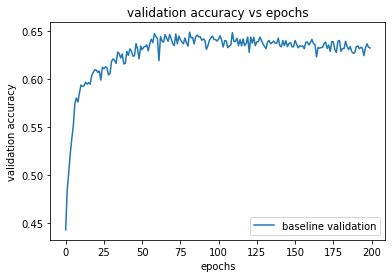

```python
plt.plot(model1_fit.history['val_sparse_categorical_accuracy'])
plt.title('validation accuracy vs epochs')
plt.ylabel('validation accuracy')
plt.xlabel('epochs')
plt.legend(['baseline validation'], loc='lower right')
plt.show()
```

**Augmented Data**

```python
(xtrain , ytrain) , (xtest , y_test) = tf.keras.datasets.cifar10.load_data()
```

```python
xtrain.shape
```

```
(50000, 32, 32, 3)
```

```python
# ref: https://chatbotslife.com/cnn-image-classification-using-cifar-10-dataset-on-google-colab-tpu-750da8cd8510

#normalizing the inputs to 0.0 - 1.0 from 0 to 255
xtrain = xtrain.astype('float32')
xtest = xtest.astype('float32')

xtrain = xtrain/255.0
xtest = xtest/255.0
```

```python
xtrain.shape
```

```
(50000, 32, 32, 3)
```

```python
xtrain, xval, ytrain, yval = train_test_split(xtrain, ytrain, test_size=0.10, random_state=25)
```

```python
xtrain.shape, xval.shape
```

```
((45000, 32, 32, 3), (5000, 32, 32, 3))
```

**Increased Brightness**

```python
xtrain_aug1 = np.minimum(1.1*xtrain,1)
```

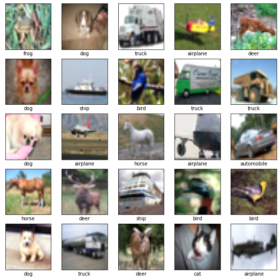

```python
label_names = ['airplane', 'automobile', 'bird', 'cat', 'deer',
               'dog', 'frog', 'horse', 'ship', 'truck']

plt.figure(figsize=(10,10))
for i in range(25):
    plt.subplot(5,5,i+1)
    plt.xticks([])
    plt.yticks([])
    plt.grid(False)
    plt.imshow(xtrain_aug1[i], cmap=plt.cm.binary)
    plt.xlabel(label_names[ytrain[i][0]])
plt.show()
```

**Decreaded Brightness**

```python
xtrain_aug2 = 0.9*xtrain
```

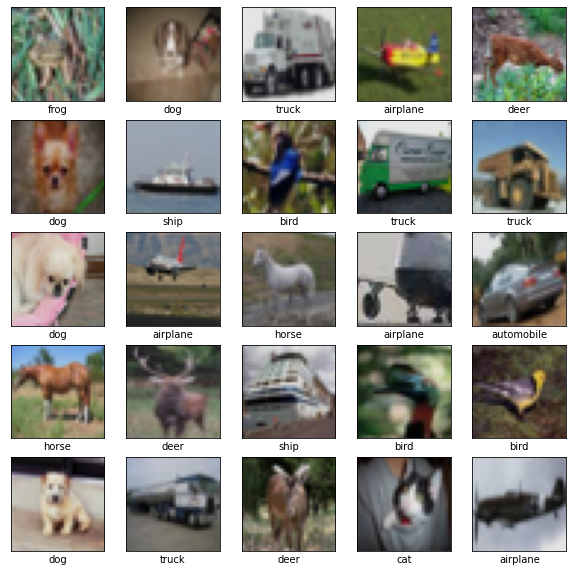

```python
label_names = ['airplane', 'automobile', 'bird', 'cat', 'deer',
               'dog', 'frog', 'horse', 'ship', 'truck']

plt.figure(figsize=(10,10))
for i in range(25):
    plt.subplot(5,5,i+1)
    plt.xticks([])
    plt.yticks([])
    plt.grid(False)
    plt.imshow(xtrain_aug2[i], cmap=plt.cm.binary)
    plt.xlabel(label_names[ytrain[i][0]])
plt.show()
```

**Image Flip**

```python
xtrain_aug3 = tf.image.flip_left_right(xtrain)
```

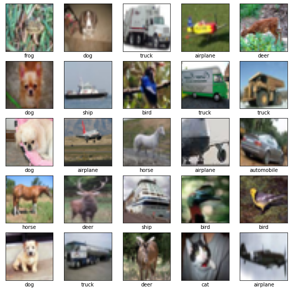

```python
label_names = ['airplane', 'automobile', 'bird', 'cat', 'deer',
               'dog', 'frog', 'horse', 'ship', 'truck']

plt.figure(figsize=(10,10))
for i in range(25):
    plt.subplot(5,5,i+1)
    plt.xticks([])
    plt.yticks([])
    plt.grid(False)
    plt.imshow(xtrain_aug3[i], cmap=plt.cm.binary)
    plt.xlabel(label_names[ytrain[i][0]])
plt.show()
```

**Combining the different transforms with original one for augmented set**

```python
xtrain_aug = np.concatenate((xtrain_aug1, xtrain_aug2,xtrain_aug3,xtrain))
```

```python
xtrain_aug.shape
```

```
(180000, 32, 32, 3)
```

```python
#Scale values around 0 from -1 to 1
xtrain_aug = (xtrain_aug-0.5)/0.5
xval = (xval-0.5)/0.5
```

```python
ytrain_aug = np.concatenate((ytrain,ytrain,ytrain,ytrain))
```

**Model Defintion for Augmented Data**

```python
initializer = tf.keras.initializers.HeNormal()
model2 = Sequential()
model2.add(Conv2D(filters=10,kernel_size=(5,5),input_shape=xtrain.shape[1:],strides=1))
model2.add(MaxPooling2D(pool_size=(2,2),strides=2))
model2.add(Activation('relu'))
model2.add(Conv2D(filters=10,kernel_size=(5,5),strides=1))
model2.add(MaxPooling2D(pool_size=(2,2),strides=2))
model2.add(Activation('relu'))
model2.add(Flatten())
model2.add(Dense(20,kernel_initializer=initializer))
model2.add(Activation('relu'))
model2.add(Dense(10,kernel_initializer=initializer))
model2.add(Activation('softmax'))
```

```python
model2.summary()
```

```
Model: "sequential_1"
_________________________________________________________________
Layer (type)                 Output Shape              Param #
=================================================================
conv2d_2 (Conv2D)            (None, 28, 28, 10)        760
_________________________________________________________________
max_pooling2d_2 (MaxPooling2 (None, 14, 14, 10)        0
_________________________________________________________________
activation_4 (Activation)    (None, 14, 14, 10)        0
_________________________________________________________________
conv2d_3 (Conv2D)            (None, 10, 10, 10)        2510
_________________________________________________________________
max_pooling2d_3 (MaxPooling2 (None, 5, 5, 10)          0
_________________________________________________________________
activation_5 (Activation)    (None, 5, 5, 10)          0
_________________________________________________________________
flatten_1 (Flatten)          (None, 250)               0
_________________________________________________________________
dense_2 (Dense)              (None, 20)                5020
_________________________________________________________________
activation_6 (Activation)    (None, 20)                0
_________________________________________________________________
dense_3 (Dense)              (None, 10)                210
_________________________________________________________________
activation_7 (Activation)    (None, 10)                0
=================================================================
Total params: 8,500
Trainable params: 8,500
Non-trainable params: 0
_________________________________________________________________
```

```python
# sparse categorical loss is without the one hot encoded target
optimize_adam = tf.keras.optimizers.Adam()
model2.compile(optimizer=optimize_adam,loss=tf.keras.losses.sparse_categorical_crossentropy,metrics=['sparse_categorical_accuracy'])
```

```python
model2_fit = model2.fit(xtrain_aug,ytrain_aug,epochs=200,batch_size=1024,validation_data=(xval,yval))
```

```python
print(model2_fit.history.keys())
```

```
dict_keys(['loss', 'sparse_categorical_accuracy', 'val_loss', 'val_sparse_categorical_accuracy'])
```

**Plot of validation accuracy vs epochs for 'baseline' and 'augmented' models**

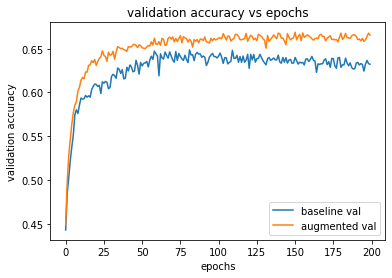

```python
plt.plot(model1_fit.history['val_sparse_categorical_accuracy'])
plt.plot(model2_fit.history['val_sparse_categorical_accuracy'])
plt.title('validation accuracy vs epochs')
plt.ylabel('validation accuracy')
plt.xlabel('epochs')
plt.legend(['baseline val','augmented val'], loc='lower right')
plt.show()
```

## **Part 2**

```python
(xtrain , ytrain) , (xtest , ytest) = tf.keras.datasets.cifar10.load_data()
```

```python
# ref: https://chatbotslife.com/cnn-image-classification-using-cifar-10-dataset-on-google-colab-tpu-750da8cd8510

#normalizing the inputs to 0.0 - 1.0 from 0 to 255
xtrain = xtrain.astype('float32')
xtest = xtest.astype('float32')

xtrain = xtrain/255.0
xtest = xtest/255.0

#Center around 0 (-1,1)
xtrain = (xtrain-0.5)/0.5
xtest = (xtest -0.5)/0.5
```

```python
xtrain.shape
```

```
(50000, 32, 32, 3)
```

```python
xtrain_aside = xtrain[49500:]
ytrain_aside = ytrain[49500:]
```

```python
xtrain_aside.shape, ytrain_aside.shape
```

```
((500, 32, 32, 3), (500, 1))
```

**Distribution of samples per class of the last 500 data images**

```python
value,labels = np.unique(ytrain_aside,return_counts=True)
dict(zip(value,labels))
```

```
{0: 42, 1: 59, 2: 40, 3: 58, 4: 43, 5: 52, 6: 47, 7: 52, 8: 59, 9: 48}
```

**class 0 preparation**

```python
xtrain_class0 = xtrain[0:49500]
```

```python
xtrain_class0.shape
```

```
(49500, 32, 32, 3)
```

```python
ytrain_class0 = np.zeros(49500)
ytrain_class0.shape
```

```
(49500,)
```

**class1 preparation**

```python
xtrain_class1 = tf.image.flip_up_down(xtrain[0:49500:])
```

```python
xtrain_class1.shape
```

```
TensorShape([49500, 32, 32, 3])
```

```python
ytrain_class1 = np.ones(49500)
ytrain_class1.shape
```

```
(49500,)
```

[output not shown]

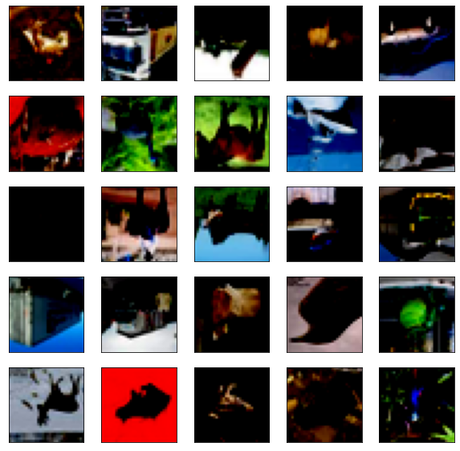

```python
label_names = ['airplane', 'automobile', 'bird', 'cat', 'deer',
               'dog', 'frog', 'horse', 'ship', 'truck']
plt.figure(figsize=(10,10))
for i in range(25):
    plt.subplot(5,5,i+1)
    plt.xticks([])
    plt.yticks([])
    plt.grid(False)
    plt.imshow(xtrain_class1[i], cmap=plt.cm.binary)
    #plt.xlabel(label_names[ytrain[i][0]])
plt.show()
```

**class2 preparation**

```python
xtrain_class2 = tf.image.rot90(xtrain[0:49500:])
xtrain_class2.shape
```

```
TensorShape([49500, 32, 32, 3])
```

```python
ytrain_class2 = np.ones(49500)*2
ytrain_class2.shape
```

```
(49500,)
```

[output not shown]

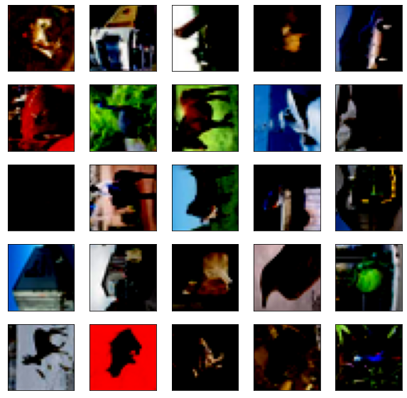

```python
label_names = ['airplane', 'automobile', 'bird', 'cat', 'deer',
               'dog', 'frog', 'horse', 'ship', 'truck']
plt.figure(figsize=(10,10))
for i in range(25):
    plt.subplot(5,5,i+1)
    plt.xticks([])
    plt.yticks([])
    plt.grid(False)
    plt.imshow(xtrain_class2[i], cmap=plt.cm.binary)
    #plt.xlabel(label_names[ytrain[i][0]])
plt.show()
```

**Adding all the classes together for unlabbled dataset**

```python
xtrain_unlablled = np.concatenate((xtrain_class0,xtrain_class1,xtrain_class2))
ytrain_unlablled = np.concatenate((ytrain_class0,ytrain_class1,ytrain_class2))
xtrain_unlablled.shape, ytrain_unlablled.shape
```

```
((148500, 32, 32, 3), (148500,))
```

**Model Defination for Unlabelled Data**

```python
initializer = tf.keras.initializers.HeNormal()
model3 = Sequential()
model3.add(Conv2D(filters=10,kernel_size=(5,5),input_shape=xtrain.shape[1:],strides=1))
model3.add(MaxPooling2D(pool_size=(2,2),strides=2))
model3.add(Activation('relu'))
model3.add(Conv2D(filters=10,kernel_size=(5,5),strides=1))
model3.add(MaxPooling2D(pool_size=(2,2),strides=2))
model3.add(Activation('relu'))
model3.add(Flatten())
model3.add(Dense(20,kernel_initializer=initializer))
model3.add(Activation('relu'))
model3.add(Dense(3,kernel_initializer=initializer))
model3.add(Activation('softmax'))
```

```python
model3.summary()
```

```
Model: "sequential"
_________________________________________________________________
Layer (type)                 Output Shape              Param #
=================================================================
conv2d (Conv2D)              (None, 28, 28, 10)        760
_________________________________________________________________
max_pooling2d (MaxPooling2D) (None, 14, 14, 10)        0
_________________________________________________________________
activation (Activation)      (None, 14, 14, 10)        0
_________________________________________________________________
conv2d_1 (Conv2D)            (None, 10, 10, 10)        2510
_________________________________________________________________
max_pooling2d_1 (MaxPooling2 (None, 5, 5, 10)          0
_________________________________________________________________
activation_1 (Activation)    (None, 5, 5, 10)          0
_________________________________________________________________
flatten (Flatten)            (None, 250)               0
_________________________________________________________________
dense (Dense)                (None, 20)                5020
_________________________________________________________________
activation_2 (Activation)    (None, 20)                0
_________________________________________________________________
dense_1 (Dense)              (None, 3)                 63
_________________________________________________________________
activation_3 (Activation)    (None, 3)                 0
=================================================================
Total params: 8,353
Trainable params: 8,353
Non-trainable params: 0
_________________________________________________________________
```

```python
# sparse categorical loss is without the one hot encoded target
optimize_adam = tf.keras.optimizers.Adam()
model3.compile(optimizer=optimize_adam,loss=tf.keras.losses.sparse_categorical_crossentropy,metrics=['sparse_categorical_accuracy'])
```

```python
model3_fit = model3.fit(xtrain_unlablled,ytrain_unlablled,epochs=100,batch_size=512)
```

**Baseline Model**

```python
initializer = tf.keras.initializers.HeNormal()
baseline = tf.keras.Sequential()
baseline.add(Conv2D(filters=10,kernel_size=(5,5),input_shape=xtrain.shape[1:],strides=1,activation='relu'))
baseline.add(MaxPooling2D(pool_size=(2,2),strides=2))
baseline.add(Conv2D(filters=10,kernel_size=(5,5),strides=1,activation='relu'))
baseline.add(MaxPooling2D(pool_size=(2,2),strides=2))
baseline.add(Flatten())
baseline.add(Dense(20,kernel_initializer=initializer,activation='relu'))
baseline.add(Dense(10,kernel_initializer=initializer,activation='softmax'))
```

```python
# sparse categorical loss is without the one hot encoded target
optimize_adam = tf.keras.optimizers.Adam()
baseline.compile(optimizer=optimize_adam,loss=tf.keras.losses.sparse_categorical_crossentropy,metrics=['sparse_categorical_accuracy'])
```

```python
baseline_fit = baseline.fit(xtrain_aside,ytrain_aside,epochs=1000,validation_data=(xtest,ytest))
```

**Plotting the test accuracy vs epochs for the baseline model with unlabelled dataset**

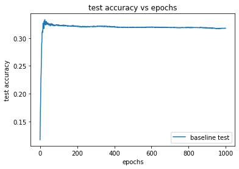

```python
plt.plot(baseline_fit.history['val_sparse_categorical_accuracy'])
plt.title('test accuracy vs epochs')
plt.ylabel('test accuracy')
plt.xlabel('epochs')
plt.legend(['baseline test'], loc='lower right')
plt.show()
```

**Transfer Learning**

```python
initializer = tf.keras.initializers.HeNormal()
transfer_model = Sequential()
transfer_model.add(Conv2D(filters=10,kernel_size=(5,5),input_shape=xtrain.shape[1:],strides=1,activation='relu'))
transfer_model.add(MaxPooling2D(pool_size=(2,2),strides=2))
transfer_model.add(Conv2D(filters=10,kernel_size=(5,5),strides=1,activation='relu'))
transfer_model.add(MaxPooling2D(pool_size=(2,2),strides=2))
transfer_model.add(Flatten())
transfer_model.add(Dense(20,kernel_initializer=initializer,activation='relu'))
```

```python
model3= Model(inputs=model3.input, outputs=model3.layers[-2].output)

#Save Keras Weights

model3.save_weights('my_model3.h5')
```

**Loading weights into the transfer model**

```python
transfer_model.load_weights('my_model3.h5')
```

```python
transfer_model.add(Dense(10,activation='softmax',kernel_initializer=initializer))
```

```python
transfer_model.summary()
```

```
Model: "sequential_2"
_________________________________________________________________
Layer (type)                 Output Shape              Param #
=================================================================
conv2d_4 (Conv2D)            (None, 28, 28, 10)        760
_________________________________________________________________
max_pooling2d_4 (MaxPooling2 (None, 14, 14, 10)        0
_________________________________________________________________
conv2d_5 (Conv2D)            (None, 10, 10, 10)        2510
_________________________________________________________________
max_pooling2d_5 (MaxPooling2 (None, 5, 5, 10)          0
_________________________________________________________________
flatten_2 (Flatten)          (None, 250)               0
_________________________________________________________________
dense_4 (Dense)              (None, 20)                5020
_________________________________________________________________
dense_5 (Dense)              (None, 10)                210
=================================================================
Total params: 8,500
Trainable params: 8,500
Non-trainable params: 0
_________________________________________________________________
```

```python
optimizer_adam = tf.keras.optimizers.Adam()
transfer_model.compile(optimizer=optimizer_adam,loss=tf.keras.losses.sparse_categorical_crossentropy,metrics=['sparse_categorical_accuracy'])
```

```python
transfer_model_fit = transfer_model.fit(xtrain_aside,ytrain_aside,epochs=1000,validation_data=(xtest,ytest))
```

**Plotting accuracy vs epochs for baseline model and transfer learning model**

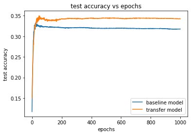

```python
plt.plot(baseline_fit.history['val_sparse_categorical_accuracy'])
plt.plot(transfer_model_fit.history['val_sparse_categorical_accuracy'])
plt.title('test accuracy vs epochs')
plt.ylabel('test accuracy')
plt.xlabel('epochs')
plt.legend(['baseline model','transfer model'], loc='lower right')
plt.show()
```

**Same graph as above for every 100th epoch**

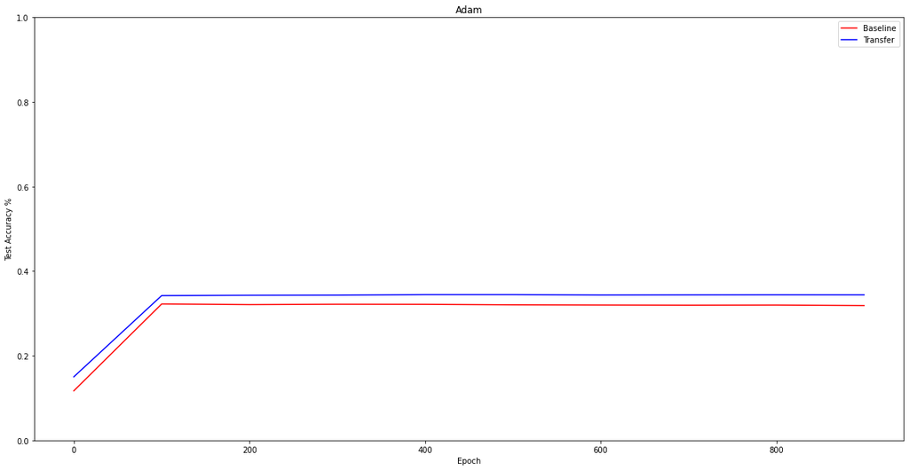

```python
Ref: https://machinelearningmastery.com/display-deep-learning-model-training-history-in-keras/
baseline_list = []
for i in range(0,1000,100):
  baseline_list.append(baseline_fit.history['val_sparse_categorical_accuracy'][i])

transfer_list = []
for i in range(0,1000,100):
  transfer_list.append(transfer_model_fit.history['val_sparse_categorical_accuracy'][i])

epochs = range(0,1000,100)
plt.figure(figsize=(20,10))
plt.plot(epochs, baseline_list, 'r', label='Baseline')
plt.plot(epochs, transfer_list, 'b', label='Transfer')
plt.axis([None, None, 0, 1])
plt.title('Adam')
plt.xlabel('Epoch')
plt.ylabel('Test Accuracy %')
plt.legend()
plt.show()
```

## **Part 3**

```python
train_loc = '/content/drive/MyDrive/Deep_Learning/tr/'
val_loc = '/content/drive/MyDrive/Deep_Learning/v/'
test_loc = '/content/drive/MyDrive/Deep_Learning/te/'
```

```python
tr_lis = os.listdir(train_loc)
tr_lis.sort()
```

```python
import math
```

**Loading the train noise data and converting all the audio signals to same length by padding with the max length audio signal.**

```python
train_noise = []
for i in range(1200):
    s, sr = librosa.load(train_loc+tr_lis[i], sr=None)
    Si = librosa.stft(s, n_fft=1024, hop_length=512)
    Si = np.abs(Si)
    #r = math.ceil(Si.shape[1]/10)*10
    padding = np.ones((513,178))*(0.000001)
    padding[:, :Si.shape[1]] = Si
   # padding = padding.reshape((int(r/10),10,513))
    train_noise.append(padding.T)
```

**Loading the train clean data and converting all the audio signals to same length by padding with the max length audio signal.**

```python
train_clean = []
for i in range(1200,2400):
    s, sr = librosa.load(train_loc+tr_lis[i], sr=None)
    Si = librosa.stft(s, n_fft=1024, hop_length=512)
    Si = np.abs(Si)
    #r = math.ceil(Si.shape[1]/10)*10
    padding = np.ones((513,178))*(0.000001)
    padding[:, :Si.shape[1]] = Si
    #padding = padding.reshape((int(r/10),10,513))
    train_clean.append(padding.T)
```

**Loading the train noisy(clean+noise) data and converting all the audio signals to same length by padding with the max length audio signal.**

```python
train_noisy = []
for i in range(2400,3600):
    s, sr = librosa.load(train_loc+tr_lis[i], sr=None)
    Si = librosa.stft(s, n_fft=1024, hop_length=512)
    Si = np.abs(Si)
    #r = math.ceil(Si.shape[1]/10)*10
    padding = np.ones((513,178))*(0.000001)
    padding[:, :Si.shape[1]] = Si
    #padding = padding.reshape((int(r/10),10,513))
    train_noisy.append(padding.T)
```

**IBM Calculation**

```python
def ibm_conversion(clean_signal,noise_signal):
  ibm = np.zeros((clean_signal.shape))
  ibm[clean_signal > noise_signal] = 1
  return ibm
```

```python
train_ibm_label = []
for j in range(1200):
  ibm = ibm_conversion(train_clean[j], train_noise[j])
  train_ibm_label.append(ibm)
```

**Stacking the noisy data and ibm labels**

```python
ytrain = np.stack(train_ibm_label)
Xtrain = np.stack(train_noisy)
```

```python
Xtrain.shape
```

```
(1200, 178, 513)
```

```python
ytrain.shape
```

```
(1200, 178, 513)
```

**Defining the GRU Model**

```python
gru_model = tf.keras.Sequential();
gru_model.add(layers.GRU(513, return_sequences=True))
gru_model.add(layers.Dropout(rate = 0.2))
gru_model.add(layers.GRU(600, return_sequences=True))
gru_model.add(layers.Dropout(rate = 0.2))
gru_model.add(layers.Dense(513, activation='sigmoid',kernel_initializer=tf.keras.initializers.GlorotNormal()))
```

```python
gru_model.compile(optimizer = tf.keras.optimizers.Adam(learning_rate=0.001), loss = tf.keras.losses.BinaryCrossentropy())
gru_model.fit(Xtrain, ytrain, epochs=50, batch_size=10)
```

```
<keras.callbacks.History at 0x7f171032e810>
```

**Validation Set**

```python
val_lis = os.listdir(val_loc)
val_lis.sort()
```

**Loading the validation noise data and converting all the audio signals to same length by padding with the max length audio signal.**

```python
val_noise = []
val_noise_ab=[]
for i in range(1200):
    s, sr = librosa.load(val_loc+val_lis[i], sr=None)
    Si = librosa.stft(s, n_fft=1024, hop_length=512)
    #r = math.ceil(Si.shape[1]/10)*10
    padding = np.ones((513,178))*(0.000001+0.000001j)
    padding[:, :Si.shape[1]] = Si
   #padding = padding.reshape((int(r/10),10,513))
    val_noise.append(padding.T)
    val_noise_ab.append(np.abs(padding.T))
```

**Loading the validation clean data and converting all the audio signals to same length by padding with the max length audio signal.**

```python
val_clean = []
val_clean_ab=[]
sum=0
r_list = [0]
for i in range(1200,2400):
    s, sr = librosa.load(val_loc+val_lis[i], sr=None)
    Si = librosa.stft(s, n_fft=1024, hop_length=512)
    #r = math.ceil(Si.shape[1]/10)*10
    padding = np.ones((513,178))*(0.000001+0.000001j)
    padding[:, :Si.shape[1]] = Si
    #padding = padding.reshape((int(r/10),10,513))
    val_clean.append(Si)
    val_clean_ab.append(np.abs(padding.T))
```

**Loading the validation noisy(clean+noise) data and converting all the audio signals to same length by padding with the max length audio signal.**

```python
val_noisy = []
val_noisy_ab=[]
for i in range(2400,3600):
    s, sr = librosa.load(val_loc+val_lis[i], sr=None)
    Si = librosa.stft(s, n_fft=1024, hop_length=512)
    #r = math.ceil(Si.shape[1]/10)*10
    padding = np.ones((513,178))*(0.000001+0.000001j)
    padding[:, :Si.shape[1]] = Si
    #padding = padding.reshape((int(r/10),10,513))
    val_noisy.append(padding.T)
    val_noisy_ab.append(np.abs(padding.T))
```

**IBM Calcluation**

```python
val_ibm_label = []
for j in range(1200):
  ibm = ibm_conversion(val_clean_ab[j], val_noise_ab[j])
  val_ibm_label.append(ibm)
```

```python
yval = np.stack(val_ibm_label)
Xval = np.stack(val_noisy_ab)
```

```python
(Xval.shape, yval.shape)
```

```
((1200, 178, 513), (1200, 178, 513))
```

**Validation Evaluation**

```python
gru_model.evaluate(Xval, yval, batch_size=10)
```

```
0.20828042924404144
```

**Generating the Mask (M)**

```python
masking = gru_model.predict(Xval, batch_size=10)
```

```python
masking.shape
```

```
(1200, 178, 513)
```

**Creating the stacked Xval i.e the noisy data**

```python
Xval_complex = np.stack(val_noisy)
```

```python
Xval_complex.shape
```

```
(1200, 178, 513)
```

**Caclulating the Shat using mask and stacked Xval**

```python
SRecon = np.multiply(masking,Xval_complex)
```

```python
SRecon[0].shape
```

```
(178, 513)
```

```python
val_clean[1].shape
```

```
(513, 65)
```

```python
def SNR_func(y,ypred):
  num = np.sum(np.square(y))
  dem = np.sum(np.square(y-ypred))
  return 10 * np.log10(num/dem)
```

**Calculating all the SNR values**

```python
mean_snr = 0
for i in range(1200):
    print(i)
    s, sr = librosa.load(val_loc+val_lis[i], sr=None)
    Si = librosa.stft(s, n_fft=1024, hop_length=512)
    clean = librosa.istft(val_clean[i],hop_length=512)
    Shat = SRecon[i]
    Shat = Shat[:Si.shape[1]]
    recon = librosa.istft(Shat.T,hop_length=512)
    new_snr = SNR_func(clean, recon)
    print(new_snr)
    mean_snr += new_snr

mean_snr /= 1200
```

[output not shown]

[output cut: 2345 more lines]

[output not shown]

**Average SNR Value**

```python
mean_snr
```

```
11.671268928826034
```

**Test Data**

```python
test_lis = os.listdir(test_loc)
test_lis.sort()
```

**Loading the test noisy data and converting all the audio signals to same length by padding with the max length audio signal.**

```python
test_noisy = []
test_noisy_ab=[]
for i in range(len(test_lis)):
    s, sr = librosa.load(test_loc+test_lis[i], sr=None)
    Si = librosa.stft(s, n_fft=1024, hop_length=512)
    #r = math.ceil(Si.shape[1]/10)*10
    padding = np.ones((513,195))*(0.000001+0.000001j)
    padding[:, :Si.shape[1]] = Si
    #padding = padding.reshape((int(r/10),10,513))
    test_noisy.append(padding.T)
    test_noisy_ab.append(np.abs(padding.T))
```

```python
X_test = np.stack(test_noisy_ab)
```

**Generating the masked test data**

```python
masking = gru_model.predict(X_test,batch_size=10)
```

**Calculating the Srecon from masked test data and noisy test data**

```python
X_test_complex = np.stack(test_noisy)
SRecon = np.multiply(masking,X_test_complex)
```

```python
import soundfile as sf
final_path = '/content/drive/MyDrive/Deep_Learning/te-clean/'
for i in range(400):
    s, sr = librosa.load(test_loc+test_lis[i], sr=None)
    recon = librosa.istft(SRecon[i].T, hop_length=512)
    recon = recon[:len(s)]
    sf.write(final_path+test_lis[i]+"_cleaned.wav", recon, sr)
```

**Conclusion: The validation average SNR value is around 12 which is a good indicator that the signals generated have a less disturbance and close resemblance with the clean signals. I also listened to the generated test clean signals and they are much better that the original noisy test signals.**

```python
%%shell
jupyter nbconvert --to html /content/DeepLearning_Assignment2_Ajinkya-3.ipynb
```